# Script to analyse the frequency data and associate with features.

- Read the csv files
- Perform necessary calcuations *Plot results (eventually new script)

setwd(‘/Users/hopla/project-master/project/gitpleuni/bachelerProject/Rscripts’)

```r
source('./baseRscript.R')
```

[output not shown]

*Read the stored frequencies rather than calculating frequencies again*

```r
if (TRUE){#read the stored data
read.table("../Output/freqPatSiteInclDay0.csv",sep=",",header=TRUE,row.names=1)->freqPatSite
read.table("../Output/freqPatTsInclDay0.csv",sep=",",header=TRUE,row.names=1)->freqPatTs
read.table("../Output/freqPatTvInclDay0.csv",sep=",",header=TRUE,row.names=1)->freqPatTv


read.table("../Output/freqPatTsInclDay0-version2.csv",sep=",",header=TRUE,row.names=1)->freqPatTsv2 #replacing the ts with the new version2
read.table("../Output/freqPatTsInclDay0-version3.csv",sep=",",header=TRUE,row.names=1)->freqPatTsv3 #replacing the ts with the new version3

}
```

*Calculate mean freq for each site and bootstrap*

```r
#Get mean
#Calculate mean freq for each site
attach(freqPatSite); colMeans<-apply(freqPatSite, 2 , mean, na.rm=TRUE)
attach(freqPatTs); colMeansTs<-apply(freqPatTs, 2 , mean, na.rm=TRUE)
attach(freqPatTv); colMeansTv<-apply(freqPatTv, 2 , mean, na.rm=TRUE)
attach(freqPatTsv2); colMeansTsv2<-apply(freqPatTsv2, 2 , mean, na.rm=TRUE)
attach(freqPatTsv3); colMeansTsv3<-apply(freqPatTsv3, 2 , mean, na.rm=TRUE)
#Get conf intervals by bootsstrapping
#PSP Nov 11 2015: I don't think we need te bootstrapping, so I put it in an if (FALSE) statement.
#ts
if (FALSE){
btmeansTs<-data.frame(row.names=names(freqPatTs)[1:984]) #each row is a site, each column is a bootstrapped mean
numbootstraps=1000
for (j in 1:984){# start with the first site
    print(j)  #kristof
for (k in 1:numbootstraps){ # first iteration
  btmeansTs[j,k]=mean(sample(freqPatTs[,j],length(freqPatTs[,j]),replace = TRUE),na.rm=TRUE)
}}
btmeansSorted<-t(apply(btmeansTs,1,sort))
lowerConf<-btmeansSorted[,floor(0.025*numbootstraps)]
upperConf<-btmeansSorted[,floor((1-0.025)*numbootstraps)]

#tv
btmeansTv<-data.frame(row.names=names(freqPatTv)[1:984]) #each row is a site, each column is a bootstrapped mean
numbootstraps=1000
for (j in 1:984){# start with the first site
    print(j)  #kristof
for (k in 1:numbootstraps){ # first iteration
  btmeansTv[j,k]=mean(sample(freqPatTv[,j],length(freqPatTv[,j]),replace = TRUE),na.rm=TRUE)
}}
btmeansSortedtv<-t(apply(btmeansTv,1,sort))
lowerConf<-btmeansSortedtv[,floor(0.025*numbootstraps)]
upperConf<-btmeansSortedtv[,floor((1-0.025)*numbootstraps)]

## ts+tv
btmeans<-data.frame(row.names=names(freqPatSite)[1:984]) #each row is a site, each column is a bootstrapped mean
numbootstraps=1000
for (j in 1:984){# start with the first site
    print(j)  #kristof
for (k in 1:numbootstraps){ # first iteration
  btmeans[j,k]=mean(sample(freqPatSite[,j],length(freqPatSite[,j]),replace = TRUE),na.rm=TRUE)
}}
btmeansSortedall<-t(apply(btmeans,1,sort))
lowerConf<-btmeansSortedall[,floor(0.025*numbootstraps)]
upperConf<-btmeansSortedall[,floor((1-0.025)*numbootstraps)]
}
```

- Transition function*

```r
#PSP Nov 11 2015 I moved the transition function to the baseRscript.R file
#transition<-function(nuc){
 # if (nuc=="a") return("g")
 # if (nuc=="g") return("a")
 # if (nuc=="c") return("t")
 # if (nuc=="t") return("c")
#}
```

## Method 1: original by Pleuni

Considering transitions and fourfold degenerate sites PSP Nov 11 2015: We don’t use this method to determine which sites are 4-fold degenerate anymore so I put it in an if (FALSE) statement

*Which are the fourfold degenerate sites?* Make list of fourfoldsites (i.e third codon positios where any substitution results in the same AA, based on positions 1 and 2) This does actually take into account transversions, which are not considered here.

```r
if (FALSE){
ListFourFold<-c("gc","cg","gg","ct","cc","tc", "ac","gt")
firstsites<-seq(1,984,by=3); secondsites<-seq(2,984,by=3);
firstandsecondpos<-sort(c(firstsites,secondsites)) ## added by Kristof
fourfoldsites=c(); otherthirdpossites=c();
for (l in firstsites){
    if (length(grep(paste(consensusB[l:(l+1)],collapse=""),ListFourFold))>0){fourfoldsites<-c(fourfoldsites,l+2);}
    else(otherthirdpossites<-c(otherthirdpossites,l+2))
}

#make vector of the type of sites*

TypeOfSite<-rep(0,984)
TypeOfSite[fourfoldsites]<-4
TypeOfSite[firstsites]<-2
TypeOfSite[secondsites]<-2
TypeOfSite[otherthirdpossites]<-3
#make sure that resistance sites in RT have a diff type of site
TypeOfSite[sort(c((RTImuts$pos*3)-2,(RTImuts$pos*3)-1,(RTImuts$pos*3)))+297]<-5
}
```

*Make plot* PSP: Nov 2015 The code for this plot (MeanFreqsFigForNSFPropInclDay0.pdf) needs the confidence intervals. I therefore also wrapped it in an if (FALSE) statement.

```r
if (FALSE){
pdf("MeanFreqsFigForNSFPropInclDay0.pdf",width = 8, height=4)
#jpeg("MeanFreqsFigForNSFProp.jpeg", width = 480, height = 480)
#par(mfrow=c(3,1))
numsitesinplot=18
#for (startsite in seq(298,(984-24),by=numsitesinplot)){
startsite = 898+3
  print(startsite)
  sitestoplot<-startsite:(startsite+numsitesinplot-1) #always start with the beginning of a codon!
  firstcodon=(startsite+2)/3; if (firstcodon>99)firstcodon=firstcodon-99

  AAseq<-c();DegenerateTransition1<-c();DegenerateTransition2<-c();DegenerateTransition3<-c()
  for (x in seq(sitestoplot[1],sitestoplot[length(sitestoplot)],by=3)){
    codon=consensusB[x:(x+2)]
    print(x:(x+2));print(codon)
    AAseq<-c(AAseq,translate(codon))
    DegenerateTransition1<-c(DegenerateTransition1,translate (codon)==translate(c(transition(codon[1]),codon[2:3])))
    DegenerateTransition2<-c(DegenerateTransition2,translate (codon)==translate(c(codon[1],transition(codon[2]),codon[3])))
    DegenerateTransition3<-c(DegenerateTransition3,translate (codon)==translate(c(codon[1:2],transition(codon[3]))))
    #almost all transitions at the third position are degenerate
  }
  firstpossitestoplot<-sitestoplot[seq(1,length(sitestoplot),by=3)]
  secondpossitestoplot<-sitestoplot[seq(2,length(sitestoplot),by=3)]
  thirdpossitestoplot<-sitestoplot[seq(3,length(sitestoplot),by=3)]
  TypeOfSite[firstpossitestoplot[which(DegenerateTransition1)]]<-4
  TypeOfSite[secondpossitestoplot[which(DegenerateTransition2)]]<-4
  TypeOfSite[thirdpossitestoplot[which(DegenerateTransition3)]]<-4

  barplot(colMeansTs[sitestoplot],col=TypeOfSite[sitestoplot],
          space=0,width=1,ylim=c(0,0.15),xaxt="n",
          main="Mean frequency of transition mutants at 18 sites in RT",
          ylab="Mean frequency")
  xaxislocs<--0.5+(1:length(sitestoplot))
  beginningofcodon<-seq(1,length(sitestoplot),by=3)
  #show nucleotides
  axis(1, at=xaxislocs, labels= consensusB[sitestoplot] ,tick=FALSE,line=-1)
  #show codons
  axis(1, at=xaxislocs[beginningofcodon]+1, labels= firstcodon:(firstcodon+(numsitesinplot/3)-1),
       tick=FALSE,line=-9)
  axis(1, at=xaxislocs[beginningofcodon]+1.,labels=AAseq,col=1,line=-8,tick=FALSE)
  axis(1, at=xaxislocs[beginningofcodon]-0.5,labels=rep("",length(beginningofcodon)),col=2 ,lty=2,tck=0.8)
  axis(1, at=xaxislocs[beginningofcodon]-0.5,labels=rep("",length(beginningofcodon)),col=2 ,lwd=2,lty=3,tck=-0.2)

  #show conf intervals
  arrows(-0.5+(1:length(sitestoplot)), lowerConf[sitestoplot] , -0.5+(1:length(sitestoplot)), upperConf[sitestoplot],
         angle=90, length=0.05, code=3)

  axis(1, at=xaxislocs[c(3,4,10,11,14,16)],labels=c("(1)","(2)","(3)","(4)","(4)","(5)"),col=1 ,line=0,tick=FALSE)

dev.off()
}
```

## Method 2: original update by Pleuni

Only synonymous, non-synomous and stop codons are considered - for each mutation, determine whether it is synonymous, non-synonymous or creates a stop - add information on resistance positions

PSP Nov 11 2015, I moved the typeofsitefunction to baseRscript

```r
#typeofsitefunction<-function(WTcodon, mutantcodon){
#    WTAA<-translate(WTcodon)
#    MUTAA<-translate(mutantcodon)
#    if (WTAA == MUTAA) return ("syn")
#    else if (MUTAA == "*") return ("stop")
#    else return ("nonsyn")
#}
```

```r
TypeOfSite<-c()
for (codon in 1:(984/3)){#for each codon in the sequence
    positions <- c(codon*3-2,codon*3-1, codon*3)
    WTcodon <- consensusB[positions]
    mutant1codon <- c(transition(WTcodon[1]), WTcodon[2:3])
    mutant2codon <- c(WTcodon[1],transition(WTcodon[2]), WTcodon[3])
    mutant3codon <- c(WTcodon[1:2], transition(WTcodon[3]))
    TypeOfSite<-c(TypeOfSite,typeofsitefunction(WTcodon,mutant1codon))
    TypeOfSite<-c(TypeOfSite,typeofsitefunction(WTcodon,mutant2codon))
    TypeOfSite<-c(TypeOfSite,typeofsitefunction(WTcodon,mutant3codon))
}
```

```r
#make sure that resistance sites in RT have a diff type of site
TypeOfSite[sort(c((RTImuts$pos*3)-2,(RTImuts$pos*3)-1,(RTImuts$pos*3)))+297]<-"res"
```

```r
#PSP Nov 11 2015 I removed lowerConf and upperConf here because we no longer calculate them
#x<-data.frame(num=1:984,colMeansTs,TypeOfSite,lowerConf,upperConf)
#PSP Nov 11 2015 I renamed x OverviewDF and newdata OverviewDFOrderedByFreq
OverviewDF<-data.frame(num=1:984,colMeansTs,colMeansTsv2,colMeansTsv3, TypeOfSite)
OverviewDFOrderedByFreq <- OverviewDF[order(colMeansTs),]
OverviewDFOrderedByFreq$color<-""
for (i in 1:984){
    if (OverviewDFOrderedByFreq$TypeOfSite[i]=="syn") OverviewDFOrderedByFreq$color[i] = "green"
    if (OverviewDFOrderedByFreq$TypeOfSite[i]=="nonsyn") OverviewDFOrderedByFreq$color[i] = "red"
    if (OverviewDFOrderedByFreq$TypeOfSite[i]=="stop") OverviewDFOrderedByFreq$color[i] = "black"
    if (OverviewDFOrderedByFreq$TypeOfSite[i]=="res") OverviewDFOrderedByFreq$color[i] = "purple"
}

#PSP Nov 11 2015 I included colMeansTsv2,colMeansTsv3 in OverviewDF and OverviewDFOrderedByFreq (previously x and newdata)
#version2 and version3: remove when not useful
#xv23<-data.frame(num=1:984,colMeansTs,colMeansTsv2,colMeansTsv3,TypeOfSite,lowerConf,upperConf)
#xv23$color<-""
#for (i in 1:984){
#    if (xv23$TypeOfSite[i]=="syn") xv23$color[i] = "green"
#    if (xv23$TypeOfSite[i]=="nonsyn") xv23$color[i] = "red"
#    if (xv23$TypeOfSite[i]=="stop") xv23$color[i] = "black"
#    if (xv23$TypeOfSite[i]=="res") xv23$color[i] = "purple"
#newdatav2 <- xv23[order(colMeansTsv2),]
#newdatav3 <- xv23[order(colMeansTsv3),]
#    }
```

## Method 3: original by Kristof

–> Trying to adapt the transition function of Pleuni, to take into account any change or transversion.

Remarks: * ‘any change’: the frequency values are not representative anymore. 1% tv -> non-syn and 99% ts -> syn will color in favor of tv, which is not representative. Solution is to work with a gradient (red -> blue), or use only tv (see below) * ‘any change’: it actually does not matter which are mutations and which is the current nucleotide. If it is a ‘a’, then substituting by ‘a’ does not make a difference. (Still to be adapted in a later stage, make the code simpeler) * ‘transversion’: can be added up to transition frequency values, and still colored differently

Still important to map * if tv: which nucleotide is used?

```r
#mutate<-function(codon){}  #trying to extend the transition function (see below) to any mutation. Still unsuccessfull.
```

*Any change calculation*

```r
nucleotides<-c('actg')
outputmatrix<-c()
for (x in seq(1,984,by=3))
{
    codon=consensusB[x:(x+2)]
        for (k in 1:3) # per codon position
        {
        mutations<-strsplit(nucleotides,"")[[1]][!strsplit(nucleotides,"")[[1]] %in% codon[k]]  # list of nucleotides that are mutations
            same<-c()
            for (m in 1:3)
            {
                      if(translate(gsub(codon[k],mutations[m],codon))=="*"){same<-c(same,"stop")}
                      else {same<-c(same,translate(codon)==translate(gsub(codon[k],mutations[m],codon)))}
                              }#change codon nucleotides
                outputmatrix<-rbind(outputmatrix,same)
            }
}
dimnames(outputmatrix)<-list(c(1:984),c('codonpos1','codonpos2','codonpos3'))  #687
```

```r
TypeOfSite_all<-c()
for (v in 1:984){
if (c(length(which(outputmatrix[v,] %in% "stop"))>0)){TypeOfSite_all<-c(TypeOfSite_all,'stop')}
else{
  if (c(length(which(outputmatrix[v,] %in% FALSE))>0)){TypeOfSite_all<-c(TypeOfSite_all,'nonsyn')}
  if (c(length(which(outputmatrix[v,] %in% FALSE))==0)){TypeOfSite_all<-c(TypeOfSite_all,'syn')}
    }
}

TypeOfSite_all[sort(c((RTImuts$pos*3)-2,(RTImuts$pos*3)-1,(RTImuts$pos*3)))+297]<-"res"
```

```r
# x_all: considering both tv and ts
#PSP Nov 11 2015 removed confidence intervals here
OverviewDF_all<-data.frame(num=1:984,colMeans,TypeOfSite_all)
OverviewDFOrderedByFreq_all <- OverviewDF_all[order(colMeans),]
OverviewDFOrderedByFreq_all$color<-""
for (i in 1:984){
    if (OverviewDFOrderedByFreq_all$TypeOfSite_all[i]=="syn") OverviewDFOrderedByFreq_all$color[i] = "green"
    if (OverviewDFOrderedByFreq_all$TypeOfSite_all[i]=="nonsyn") OverviewDFOrderedByFreq_all$color[i] = "red"
    if (OverviewDFOrderedByFreq_all$TypeOfSite_all[i]=="stop") OverviewDFOrderedByFreq_all$color[i] = "black"
    if (OverviewDFOrderedByFreq_all$TypeOfSite_all[i]=="res") OverviewDFOrderedByFreq_all$color[i] = "purple"
}
```

*Only transversions*

```r
outputmatrixtv<-c()
for (x in seq(1,984,by=3))
{
    codon=consensusB[x:(x+2)]

    for (k in 1:3)
    {   # per positie van het codon  de 3 nuc zetten
        #paste("DegenerateTransition",k,sep='')<-c()
        if (codon[k] =='a' | codon[k]=='g'){mutationstv<-c("c","t");print(mutationstv)}
        if (codon[k] =='c' | codon[k]=='t'){mutationstv<-c("a","g")}

        sametv<-c()
        #verander nucleotides in codon
        for (m in 1:2)
        {
           if(translate(gsub(codon[k],mutationstv[m],codon))=="*"){sametv<-c(sametv,"stop")}
           else {sametv<-c(sametv,translate(codon)==translate(gsub(codon[k],mutationstv[m],codon)))}
        }

        outputmatrixtv<-rbind(outputmatrixtv,sametv)
        #paste("DegenerateTransition",k,sep='') <-c(length(which(same %in% FALSE))>0)
    }
}
```

[output not shown]

[output cut: 574 more lines]

```r
dimnames(outputmatrixtv)<-list(c(1:984),1:2)
```

```r
TypeOfSite_tv<-c()
for (v in 1:984){
if (c(length(which(outputmatrixtv[v,] %in% "stop"))>0)){TypeOfSite_tv<-c(TypeOfSite_tv,'stop')}
else{
  if (c(length(which(outputmatrixtv[v,] %in% FALSE))>0)){TypeOfSite_tv<-c(TypeOfSite_tv,'nonsyn')}
  if (c(length(which(outputmatrixtv[v,] %in% FALSE))==0)){TypeOfSite_tv<-c(TypeOfSite_tv,'syn')}
    }
}
TypeOfSite_tv[sort(c((RTImuts$pos*3)-2,(RTImuts$pos*3)-1,(RTImuts$pos*3)))+297]<-"res"
```

```r
# x_tv: considering both tv and ts
#PSP Nov 11 2015 removed ,lowerConf,upperConf here
x_tv<-data.frame(num=1:984,colMeansTv,TypeOfSite_tv)
newdata_tv <- x_tv[order(colMeansTv),]
newdata_tv$color<-""
for (i in 1:984){
    if (newdata_tv$TypeOfSite_tv[i]=="syn") newdata_tv$color[i] = "green"
    if (newdata_tv$TypeOfSite_tv[i]=="nonsyn") newdata_tv$color[i] = "red"
    if (newdata_tv$TypeOfSite_tv[i]=="stop") newdata_tv$color[i] = "black"
    if (newdata_tv$TypeOfSite_tv[i]=="res") newdata_tv$color[i] = "purple"
}
```

### Is it worth adding tv to the analysis?

Determine the difference in mutation frequency between ts and tv. Not finished yet, due to git problem: i need to make it again.

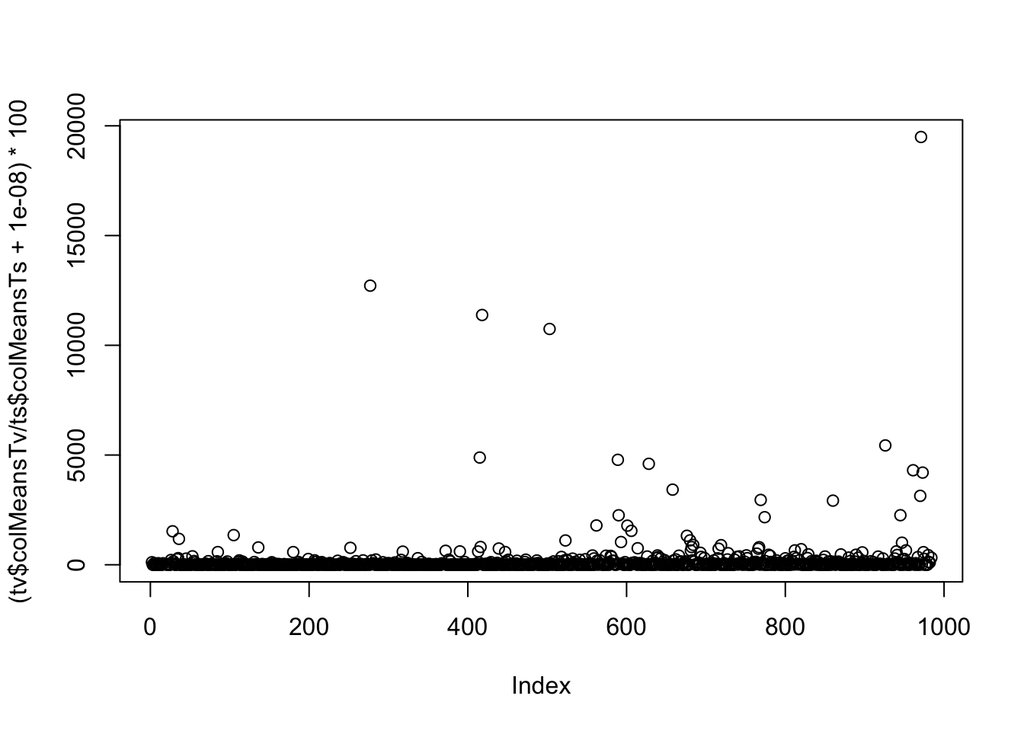

```r
#PSP Nov 11 2015: I am not sure the next lines are correct.

tv<-newdata_tv[order(newdata_tv[,1]),]
ts<-OverviewDFOrderedByFreq[order(OverviewDFOrderedByFreq[,1]),]
aa<-cbind(tv,ts,round(tv$colMeansTv/ts$colMeansTs,2));

#PSP the number of columns for aa had changed because I took out the conf intervals. had to change the code here so that the last column was renamed.
names(aa)[length(names(aa))]<-'ratio'

#to what extent occur tv relative to ts.
plot((tv$colMeansTv/ts$colMeansTs+0.00000001)*100)
```

```r
#plot the difference between all (ts+tv) and only ts
#plot(sort(log(a$colMeansTs +b$colMeansTv)),type='l')
#lines(sort(log(a$colMeansTs)),col='red')
#plot(sort((a$colMeansTs +b$colMeansTv)),type='l')
#lines(sort((a$colMeansTs)),col='red')
```

# Selecting the Protease or the Reverse transcriptase region

*PRO: Make the plots (transitions)*

```r
pdf("../Output/Protease.pdf",width = 13, height = 10)
PROdata<-OverviewDFOrderedByFreq[OverviewDFOrderedByFreq$num<298,]
#remove resistance mutations
PROdata<-PROdata[PROdata$TypeOfSite!="res",]
plot(PROdata$colMeansTs+0.001,log="y",ylim=c(0.001,0.15),cex=2, pch = "|",col=PROdata$color)
#arrows(1:length(PROdata$num), PROdata$lowerConf +0.001, 1:length(PROdata$num), PROdata$upperConf +0.001,
#       angle=90, length=0.01, code=3, col=PROdata$color,lwd=0.1)
dev.off()
```

*PRO: Make the plots (transitions) for version 2 and version 3 methods*

```r
pdf("../Output/Protease-version2.pdf",width = 13, height = 10)
#PROdatav2<-newdatav2[newdatav2$num<298,]
#PROdatav2<-PROdatav2[PROdatav2$TypeOfSite!="res",]
#PSP Nov 11 2015 we can now use PROdata instead of PROdatav2 and PROdatav3
plot(PROdata$colMeansTsv2+0.001,log="y",ylim=c(0.001,0.15),cex=2, pch = "|",col=PROdata$color)
dev.off()
```

```r
pdf("../Output/Protease-version3.pdf",width = 13, height = 10)
#PROdatav3<-newdatav3[newdatav3$num<298,]
#PROdatav3<-PROdatav3[PROdatav3$TypeOfSite!="res",]
plot(PROdata$colMeansTsv3+0.001,log="y",ylim=c(0.001,0.15),cex=2, pch = "|",col=PROdata$color)
dev.off()
```

*PRO: Make the plots (all = ts +tv): INTERMEZZO* A plot for all mutations does not work because tv dominates the coloring. option1: Use frequency of all mutations, but color according to tv versus ts ratio by using seperate color vectors option2: Use frequency of ts (order), plot ts and in addition plot tv+ts. This way, you can see for each position, the frequency of ts with its color, and the added value by tv and its color.

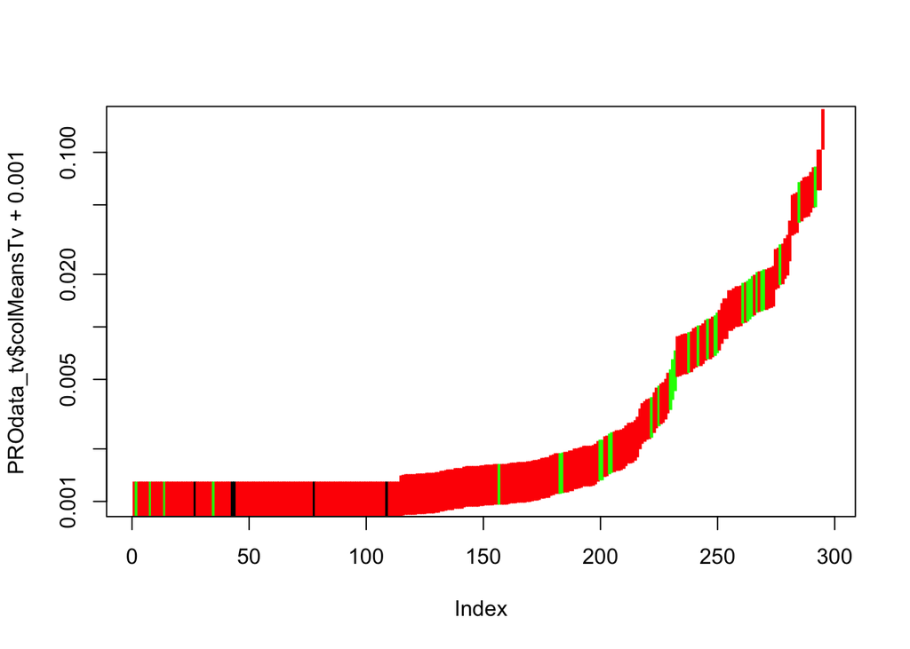

```r
#dataframe: selection of PR from the tv+ts and tv dataframe
PROdata_all<-OverviewDFOrderedByFreq_all[OverviewDFOrderedByFreq_all$num<298,]
PROdata_all<-PROdata_all[PROdata_all$TypeOfSite_all!="res",]

PROdata_tv<-newdata_tv[newdata_tv$num<298,]
PROdata_tv<-PROdata_tv[PROdata_tv$TypeOfSite_tv!="res",]
plot(PROdata_tv$colMeansTv+0.001,log="y",ylim=c(0.001,0.15),cex=2, pch = "|",col=PROdata_tv$color)
```

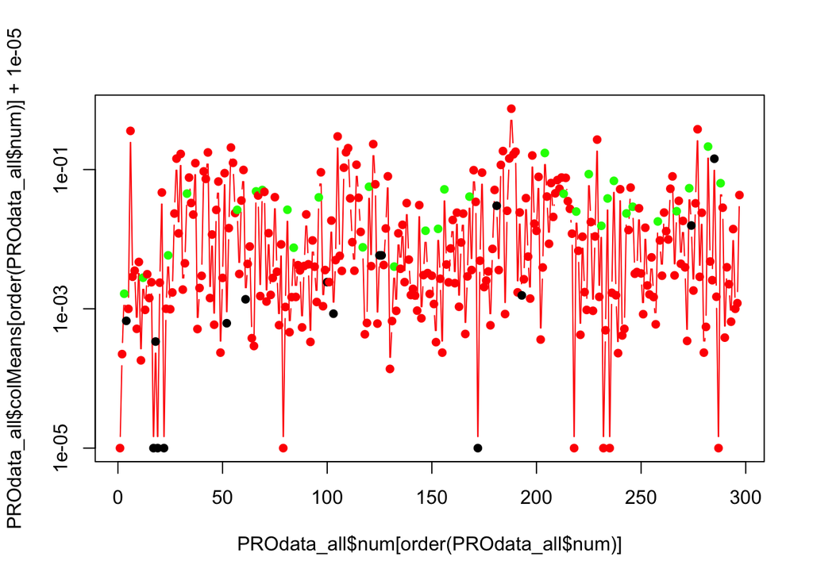

```r
# option 1 with the gradient: forget due to too much work to code it.
# we will go for option 2: plot the ts and add tv on top, (or vice versa)
# first tv+ts, then only ts-> green on top   ---! beware of the numbering. tv must be ordered similar to ts, and not according to tv frequencies.

# Ordered by position
#PSP Nov 11 2015 : please don't hard code the number of the column!
names(PROdata_tv)[which(names(PROdata_tv) == "color")]<-'colortv'
protstv<-merge(PROdata,PROdata_tv,by='num')
# Plot all positions
plot(PROdata_all$num[order(PROdata_all$num)],PROdata_all$colMeans[order(PROdata_all$num)]+0.00001,pch=16,log="y",type="b",col=PROdata_all$color[order(PROdata_all$num)])
```

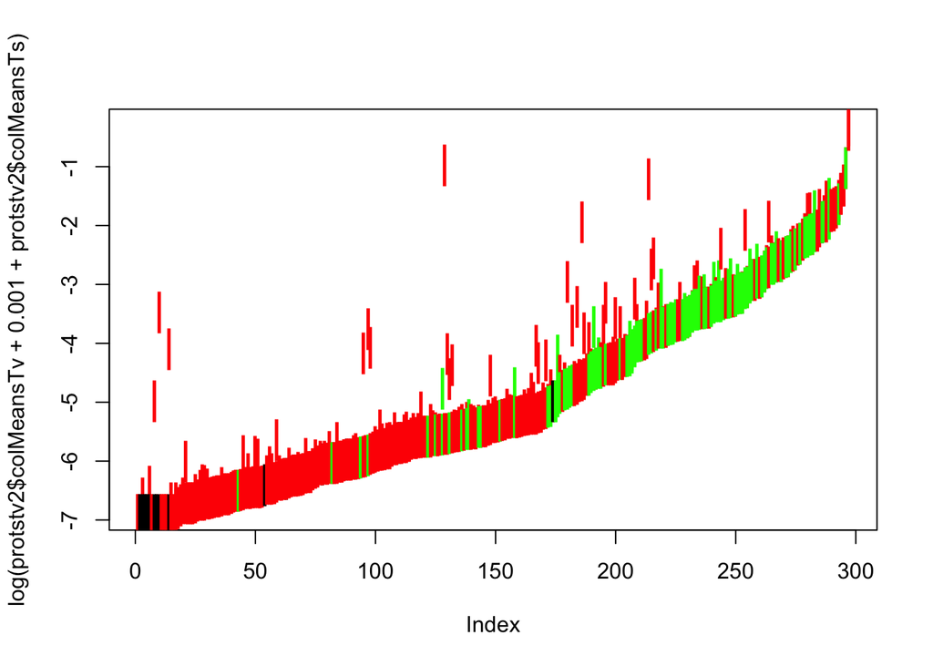

```r
# Ordered according to colMeanTs
protstv2<-protstv[order(protstv$colMeansTs),]
# first ts then ts+tv,or vice versa: important for the coloring.
plot(log(protstv2$colMeansTv+0.001+protstv2$colMeansTs),cex=2, pch = "|",col=protstv2$colortv)
points(log(protstv2$colMeansTs+0.001),cex=2, pch = "|",col=protstv2$color)
```

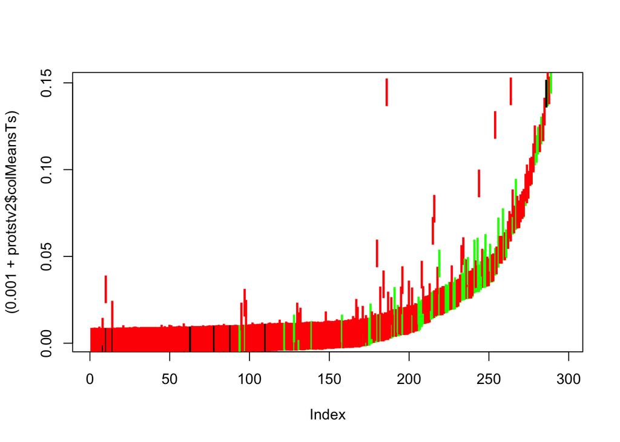

```r
plot((0.001+protstv2$colMeansTs),ylim=c(0.001,0.15),cex=2, pch = "|",col=protstv2$color)
points((protstv2$colMeansTv+0.001+protstv2$colMeansTs),cex=2, pch = "|",col=protstv2$colortv)
```

*RT: Make the plots (transitions)*

```r
pdf("../Output/RT-version.pdf",width = 13, height = 10)
RTdata<-OverviewDFOrderedByFreq[OverviewDFOrderedByFreq$num>=298,]
RTdata<-RTdata[RTdata$TypeOfSite!="res",]
plot(RTdata$colMeansTs+0.001,log="y",ylim=c(0.001,0.15),cex=1, pch = "|",col=RTdata$color)
#arrows(1:length(RTdata$num), RTdata$lowerConf +0.001, 1:length(RTdata$num), RTdata$upperConf +0.001,
#       angle=90, length=0.01, code=3, col=RTdata$color,lwd=0.1)
dev.off()
```

```r
pdf("../Output/RT-version2.pdf",width = 13, height = 10)
#RTdatav2<-newdatav2[newdatav2$num>=298,]
#RTdatav2<-RTdatav2[RTdatav2$TypeOfSite!="res",]
#PSP Nov 11 2015 RTdatav2 no longer needed ,bc included in RTdata
plot(RTdata$colMeansTsv2+0.001,log="y",ylim=c(0.001,0.15),cex=1, pch = "|",col=RTdata$color)
dev.off()
```

```r
pdf("../Output/RT-version3.pdf",width = 13, height = 10)
#RTdatav3<-newdatav3[newdatav3$num>=298,]
#RTdatav3<-RTdatav3[RTdatav3$TypeOfSite!="res",]
plot(RTdata$colMeansTsv3+0.001,log="y",ylim=c(0.001,0.15),cex=1, pch = "|",col=RTdata$color)
dev.off()
```

### Non-lethal stop codons

```r
#For protease, which are the not-lethal stop codons?

#PSP Nov  11 2015: I removed this because we o longer need it. We now have a better way to deal with double mutants (i.e. v2 and/or v3).
if (FALSE){
#head(PROdata)
PROdata[PROdata$TypeOfSite=="stop"& PROdata$colMeansTs>0,]
#site 4 and site 125
#Which codons are they part of?
plot(PROdata$colMeansT+0.001,log="y",ylim=c(0.001,0.2),cex=2, pch = "|",col=PROdata$color)

sites<-PROdata$num[PROdata$TypeOfSite=="stop"& PROdata$colMeansTs>0]
codons<-ceiling(sites/3)


# plot stop codons sites
for (codon in codons){
    positions <- c(codon*3-2,codon*3-1, codon*3)
    rows<-which(PROdata$num %in% sites)
    points(rows,PROdata$colMeansT[rows]+0.001,col=PROdata$color[rows],cex=2,pch=16)
#    print(positions)
#    WTcodon <- consensusB[positions]
#    print (WTcodon)
#    print(translate(WTcodon))
#    print(PROdataz#print frequencies
}

#points(PROdata$colMeansT+0.001)
}
```

```r
#for ease of reading
freqPatTs<-round(freqPatTs,2)
```

### Stop codons: I need to look at the original fasta files and look at the frequency of codons.

```r
list.files(path="../Data/BachelerFiles/FASTAfiles/")->listfastafiles

#PSP Nov  11 2015: I removed this because we o longer need it. We now have a better way to deal with double mutants (i.e. v2 and/or v3).

if (FALSE){
for (co in codons){#for each site in the sequence
    ListAA<-c(); ListCodon<-c()
    for (i in 1:length(listfastafiles)){ #for each fastafile
        filename=paste("../Data/BachelerFiles/FASTAfiles/",substr(listfastafiles[i],1,6),".fasta",sep="")
        #print(filename)
        patfasta<-read.dna(filename, format = "fasta",as.character=TRUE) #read the file
        if (length(patfasta[,1])>1) {
        WTcodon =   consensusB[c(co*3-2,co*3-1,co*3)]; #what is WT at site j?
        WTAA = translate(WTcodon)
        Patcodon = patfasta[,c(co*3-2,co*3-1,co*3)]
        #print(Patcodon)
        PatAA = apply(Patcodon, 1, function(x) translate(x))
        ListAA<-c(ListAA, PatAA)
        Patcodon<-apply(Patcodon, 1, function(x) paste(x,collapse=""))
        ListCodon<-c(ListCodon,Patcodon)
        }
    }
    print(paste("Codon: ", co))
    print(table(ListAA))
    print(table(ListCodon))
}
}
```

### Make an AA variability map

```r
translatedB<-translate(consensusB)
#convert the fasta files into AA sequences
translatedfasta<-c()
for (i in 1:length(listfastafiles)){ #for each fastafile
         filename=paste("../Data/BachelerFiles/FASTAfiles/",substr(listfastafiles[i],1,6),".fasta",sep="")
           patfasta<-read.dna(filename, format = "fasta",as.character=TRUE) #read the file
           translatedfasta<-rbind(translatedfasta,t(apply(patfasta,1,function(x) translate(x))))
}
```

```r
#determine for each codon position, the frequency of mutations compared to subtype B
mutations<-c()
for(m in 1:length(translatedB)){
prevmut<-100-(length(which(translatedfasta[,m]==translatedB[m]))/nrow(translatedfasta)*100)
mutations<-c(mutations,prevmut)
}
```

## Non-Syn plot

```r
pdf("../Output/PR-nonsyn.pdf",width = 13, height = 10)
PROdataNonSyn<-PROdata[PROdata$TypeOfSite=="nonsyn",]
#Make plot of Protease
plot(PROdataNonSyn$num[order(PROdataNonSyn$num)],PROdataNonSyn$colMeansTs[order(PROdataNonSyn$num)]+0.001,col=PROdataNonSyn$color[order(PROdataNonSyn$num)],pch=16,log="y",type="b")#,ylim=c(0,max(PROdataNonSyn$colMeansTs)))
#Add moving mean
for (i in 20:280){
    range = (i-20):(i+20)
#    points(i, mean(PROdataNonSyn$colMeansTs[PROdataNonSyn$num%in%range]), col="blue",pch = 12, cex=3)
    points(i, median(PROdataNonSyn$colMeansTs[PROdataNonSyn$num%in%range]), col="green",pch = 11, cex=3)
}
dev.off()
```

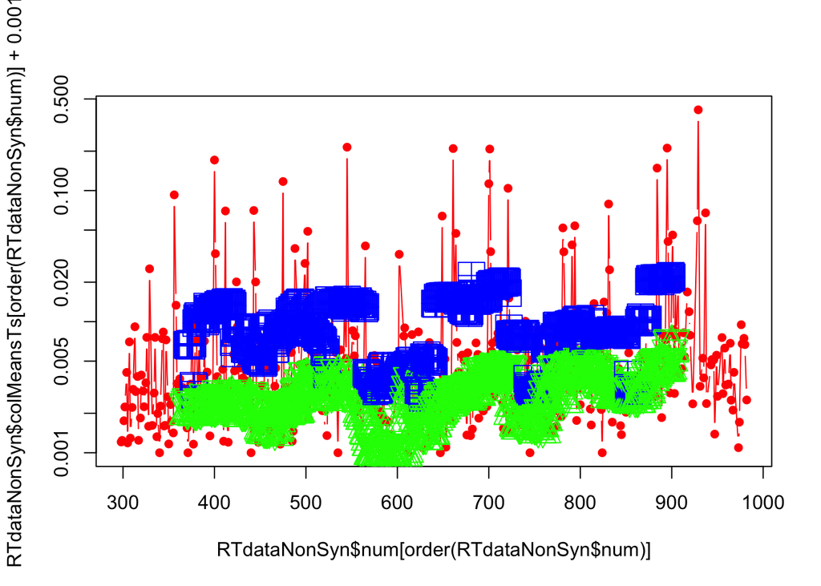

```r
RTdataNonSyn<-RTdata[RTdata$TypeOfSite=="nonsyn",]
plot(RTdataNonSyn$num[order(RTdataNonSyn$num)],RTdataNonSyn$colMeansTs[order(RTdataNonSyn$num)]+0.001,col=RTdataNonSyn$color[order(RTdataNonSyn$num)],pch=16,log="y",type="b")

#Add moving mean
for (i in 370:900){
    range = (i-20):(i+20)
    points(i, mean(RTdataNonSyn$colMeansTs[RTdataNonSyn$num%in%range]), col="blue",pch = 12, cex=3)
    points(i, median(RTdataNonSyn$colMeansTs[RTdataNonSyn$num%in%range]), col="green",pch = 11, cex=3)
}
```

```r
i=370
    range = (i-20):(i+20)
```

### Non-syn figures for version 2 and version 3

```r
#VERSION2
pdf("../Output/PR-nonsyn-version2.pdf",width = 13, height = 10)
PROdataNonSynv2<-PROdata[PROdata$TypeOfSite=="nonsyn",]
plot(PROdataNonSynv2$num[order(PROdataNonSynv2$num)],PROdataNonSynv2$colMeansTsv2[order(PROdataNonSynv2$num)]+0.001,col=PROdataNonSynv2$color[order(PROdataNonSynv2$num)],pch=16,log="y",type="b")
#Add moving mean
for (i in 20:280){
    range = (i-20):(i+20)
    points(i, median(PROdataNonSynv2$colMeansTsv2[PROdataNonSynv2$num%in%range]), col="green",pch = 11, cex=3)
}
dev.off()
```

```r
#VERSION 3
pdf("../Output/PR-nonsyn-version3.pdf",width = 13, height = 10)
PROdataNonSynv3<-PROdata[PROdata$TypeOfSite=="nonsyn",]
plot(PROdataNonSynv3$num[order(PROdataNonSynv3$num)],PROdataNonSynv3$colMeansTsv3[order(PROdataNonSynv3$num)]+0.001,col=PROdataNonSynv3$color[order(PROdataNonSynv3$num)],pch=16,log="y",type="b")
#Add moving mean
for (i in 20:280){
    range = (i-20):(i+20)
    points(i, median(PROdataNonSynv3$colMeansTsv3[PROdataNonSynv3$num%in%range]), col="green",pch = 11, cex=3)
}
dev.off()
```

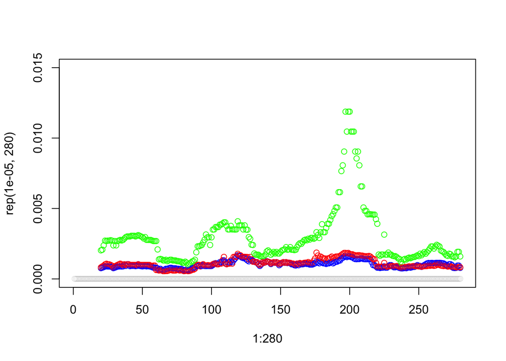

```r
## compare the medians of the three versions


plot(1:280,rep(0.00001,280),ylim=c(0,0.015),xlim=c(1,280),pch=1,lwd=0.1)
for (i in 20:280){
    range = (i-20):(i+20)
    points(i, median(PROdataNonSyn$colMeansTs[PROdataNonSyn$num%in%range]), col="green")
  points(i, median(PROdataNonSynv2$colMeansTsv2[PROdataNonSynv2$num%in%range]), col="blue")
  points(i, median(PROdataNonSynv3$colMeansTsv3[PROdataNonSynv3$num%in%range]), col="red")
    }
```

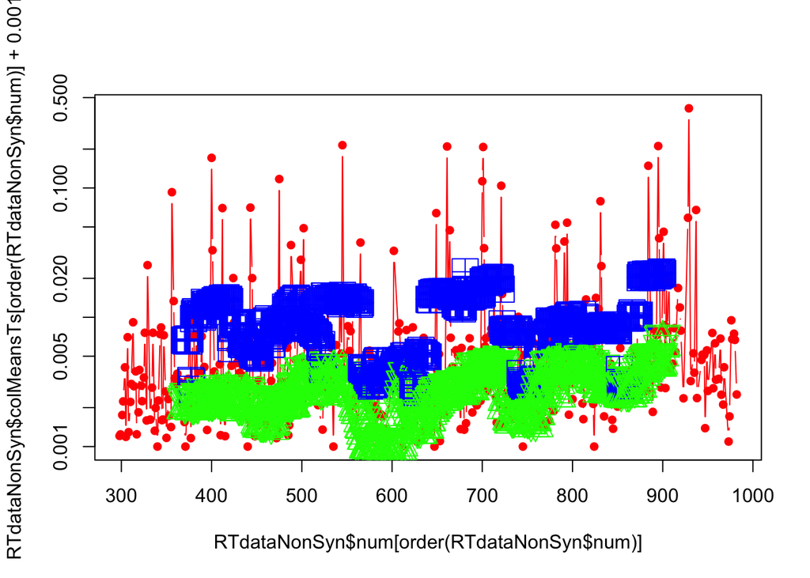

```r
## RT
RTdataNonSyn<-RTdata[RTdata$TypeOfSite=="nonsyn",]
plot(RTdataNonSyn$num[order(RTdataNonSyn$num)],RTdataNonSyn$colMeansTs[order(RTdataNonSyn$num)]+0.001,col=RTdataNonSyn$color[order(RTdataNonSyn$num)],pch=16,log="y",type="b")

#Add moving mean
for (i in 370:900){
    range = (i-20):(i+20)
    points(i, mean(RTdataNonSyn$colMeansTs[RTdataNonSyn$num%in%range]), col="blue",pch = 12, cex=3)
    points(i, median(RTdataNonSyn$colMeansTs[RTdataNonSyn$num%in%range]), col="green",pch = 11, cex=3)
}
```

```r
i=370
    range = (i-20):(i+20)
```

### Non-syn figures of transversions or of all (transversions + transitions) for version 1

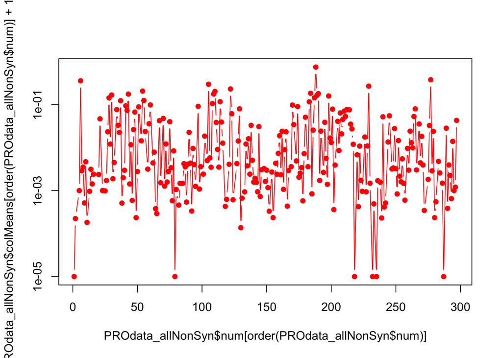

```r
# Plot only nonsyn changes (ts+tv), following the methodology of below ts nonsyn.
PROdata_allNonSyn<-PROdata_all[PROdata_all$TypeOfSite=="nonsyn",]
plot(PROdata_allNonSyn$num[order(PROdata_allNonSyn$num)],PROdata_allNonSyn$colMeans[order(PROdata_allNonSyn$num)]+0.00001,pch=16,log="y",type="b",col=PROdata_allNonSyn$color[order(PROdata_allNonSyn$num)])
```

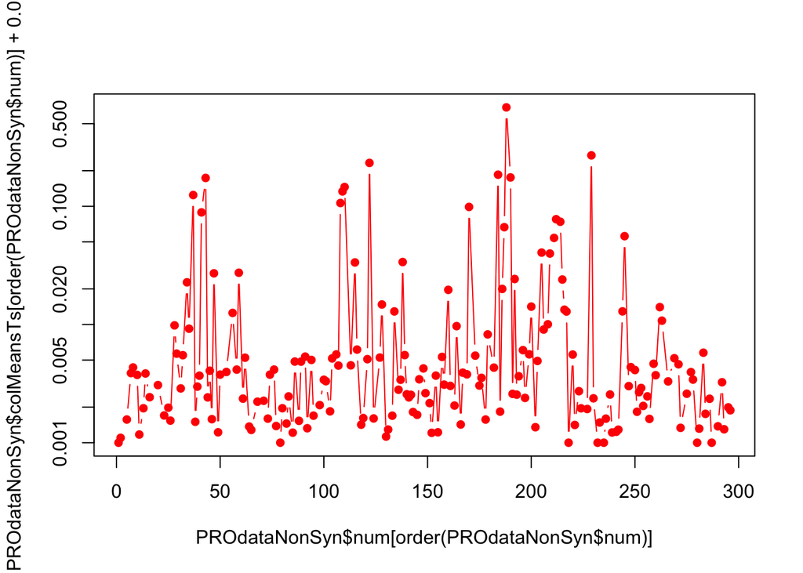

```r
# ts plot for non-syn: copy paste of code below.
PROdataNonSyn<-PROdata[PROdata$TypeOfSite=="nonsyn",]
plot(PROdataNonSyn$num[order(PROdataNonSyn$num)],PROdataNonSyn$colMeansTs[order(PROdataNonSyn$num)]+0.001,col=PROdataNonSyn$color[order(PROdataNonSyn$num)],pch=16,log="y",type="b")
```

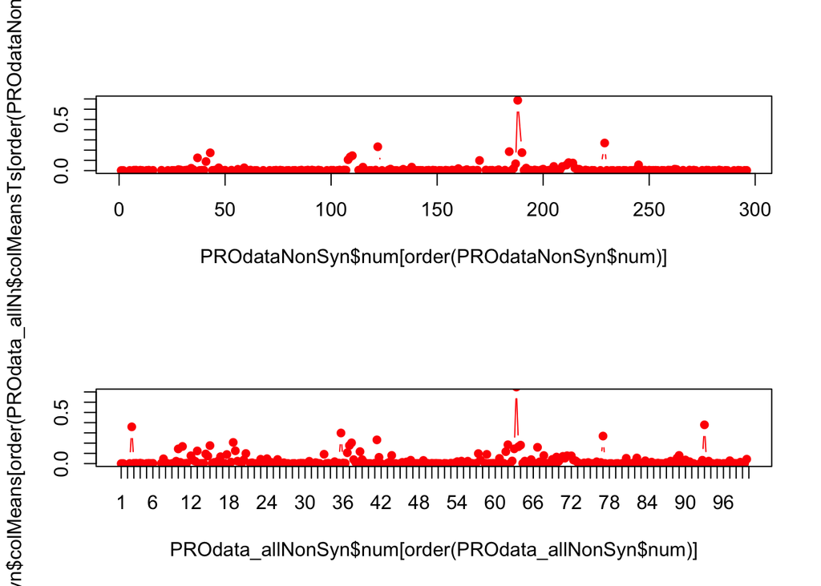

```r
#compare the ts plot of only nonsyn vs the ts+tv plot of only nonsym
# it is bit biased, since for the ts+tv plot: ts with hig freq and syn, when we add tv with log freq and nonsyn, you get favored tv.
par(mfrow=c(2,1))
plot(PROdataNonSyn$num[order(PROdataNonSyn$num)],PROdataNonSyn$colMeansTs[order(PROdataNonSyn$num)]+0.001,col=PROdataNonSyn$color[order(PROdataNonSyn$num)],pch=16,type="b",ylim=c(0,0.7))
plot(PROdata_allNonSyn$num[order(PROdata_allNonSyn$num)],PROdata_allNonSyn$colMeans[order(PROdata_allNonSyn$num)]+0.00001,pch=16,type="b",col=PROdata_allNonSyn$color[order(PROdata_allNonSyn$num)],ylim=c(0,0.7),xaxt='n')
axis(1,seq(1,298,by=3),label=1:100)
```

# Next steps

Going to randomisations - frequency-ordered figure: does the coloring scheme hold?

- position-ordered figure: does the pattern hold?

### For protease, which are the most deleterious non-syn sites?

To be done Interesting? why? for therapy or vaccine.

### For protease, which are the most neutral non-syn sites?

corresponding to the expected frequency based on sequence length * mutation rate? Frequency should flucatuate aroudn the expected value?

# For protease, which are the most deleterious syn sites?

To be done : green colored sites with low frequ Interesting why? HIV replication?